# CITS4009-Project 2

Yi REN(23895642), Di ZHANG(23897171)

The Youtube link of our presentation: https://youtu.be/X_o0rYDFQM4

## Teamwork Distribution

1. Yi REN(23895642)(50%): Data preparing, classification.
2. Di ZHANG(23897171)(50%): Clustering, Shiny app.

## Introduction

The dataset chosen is the Global YouTube Statistics 2023 and is located on Kaggle at https://www.kaggle.com/datasets/nelgiriyewithana/global-youtube-statistics-2023. The dataset contains a lot of statistics of the world’s most subscribed Youtube channels in 2023, which is very helpful for us to find some insights about some rules and trending developments about Youtube channels. As I have already done some basic data cleaning and transforming, this dataset now has 753 obs of 39 variables.

## Data loading and set up

Load libraries

```r
library(ggthemes)
library(ggplot2)
library(dplyr)
library(caret)
library(FSelectorRcpp)
library('e1071')
library(rpart)
library(rpart.plot)
library(NbClust)
library(tidyverse)
library(factoextra)
library(cluster)
```

Seetting up a plot theme so all the diagrams can look coherent

```r
library(ggthemes)
library(ggplot2)
project2_theme <- theme_few() + # Theme based on Sergio Banchero - Michael Wheeler's project example
                  theme(plot.title = element_text(color = "darkred")) +
                  theme(strip.text.x = element_text(size = 14, colour = "#202020")) +
                  theme(plot.margin=margin(10,30,10,30))
```

Load the main data

```r
data.path <- 'E:/OneDrive - The University of Western Australia/文档/Rstudio/Youtubesta(1).csv'
Youtubesta <- read.csv(data.path)
```

Discard some unique and categorical values

```r
Youtubesta2 <- Youtubesta[,-c(1,2,3,6,7,11,12,13,14)]
```

We’d like to plug a country’s social economic status to research, so we need to merge another dataset. The dataset we chose is the GDP per capita by countries, which was released by Worldbank.(source:https://data.worldbank.org/indicator/NY.GDP.PCAP.CD). This dataset includes the GDP per capita from 1960 to 2022. We will just use 2022 data to research.

```r
#Load the minor data
data.path_minor <- 'E:/OneDrive - The University of Western Australia/文档/Rstudio/API_NY.GDP.PCAP.CD_DS2_en_csv_v2_5871588.csv'
PGDP <- read.csv(data.path_minor)

#Delete unnecessary data,just remain country name and 2022 PGDP data, and omit NA
PGDP1 <- PGDP[c(1,67)]
PGDP1 <- na.omit(PGDP1)
#Merge the main data with minor data
library(dplyr)
Youtubesta3 <- left_join(Youtubesta2,PGDP1 , by = c("Country" = "Country.Name"))
Youtubesta3 <- na.omit(Youtubesta3)
```

## Part 1 - Classification

### Choosing the response variable

The response variable we have chosen is the logarithmic value of highest yearly income(highest_yearly_earnings_log). It indicates each Youtube channel’s highest estimated yearly income. To reduce the errors of data, I use logarithmic value. As I have already calculate this variable in Project 1, so in this project, we just need to transform it into binary data(hyel_binary). Firstly, I will find the median of ‘hyil_binary’. Secondly, I will assign the variables 0/1 , 0 for the values that lower than median and 1 for these higher than median.

```r
#discard some outliers(cite1:Chatgpt 3.5)
library(dplyr)
z_threshold <- 3
Youtubesta4 <- Youtubesta3 %>%
  mutate(z_score = (highest_yearly_earnings_log - mean(highest_yearly_earnings_log)) / sd(highest_yearly_earnings_log))
Youtubesta5 <- Youtubesta4 %>%
  filter(abs(z_score) <= z_threshold) %>%
  select(-z_score)

#calculate the median
hyel_median <- median(Youtubesta5$highest_yearly_earnings_log)

#create a new binary data based on the comparison to the median
Youtubesta5$hyel_binary <- ifelse(Youtubesta5$highest_yearly_earnings_log > hyel_median, 1, 0)
table(Youtubesta5$hyel_binary)
```

```
##
##   0   1
## 340 332
```

Looking at the proportions of outcome target variables selected, we can see that there is an equal split.

### Selecting the features

In this part, we will create a “candidate columns” to store some “candidate variables” that we think might affect the target variable, and then we will use some feature selection techniques to select the most relevant features from the candidate variables.Firstly, we will use Fisher’s score.

```r
#Fisher's score(cite2:chatgpt 3.5)
library(caret)
candidate_columns <- c("subscribers","video.views","uploads","subscribers_for_last_30_days","Gross.tertiary.education.enrollment....","Population","Unemployment.rate","Urban_population","highest_monthly_earnings_fix1","videoviews_monthlygrowthrate","videoviews_uploads","earnings_views","created_year","X2022")
Youtubesta5 <- na.omit(Youtubesta5) #omit NA values to make sure the calculation can be executed
Youtubesta5$uploads <- as.numeric(Youtubesta5$uploads) #convert some values into numerical values
Youtubesta5$video.views <- as.numeric(Youtubesta5$video.views) #make sure it's numeric value
Youtubesta5$subscribers_for_last_30_days <- as.numeric(Youtubesta5$subscribers_for_last_30_days)
candidate_features <- Youtubesta5[, candidate_columns]
candidate_features_nona <- na.omit(candidate_features)
custom_fisher_column <- function(x, y) { #define a function to calculate fisher score
  abs(tapply(x, y, mean) - mean(x)) / (tapply(x, y, var) + var(x))
}
fisher_scores_list <- lapply(candidate_features_nona, custom_fisher_column, y = Youtubesta5$hyel_binary)
fisher_scores_df <- data.frame(Feature = colnames(candidate_features_nona), Fisher_Score = unlist(fisher_scores_list))
ranked_features1 <- fisher_scores_df[order(fisher_scores_df$Fisher_Score, decreasing = TRUE), ] #order features in descending order
selected_features1 <- ranked_features1$Feature[1:4] #select the 4 features with highest fisher score
```

After the fisher’s score selection, we get the first combination of features which is shown below.

```r
selected_features1
```

```
## [1] "highest_monthly_earnings_fix1"
## [2] "videoviews_monthlygrowthrate"
## [3] "Gross.tertiary.education.enrollment...."
## [4] "Population"
```

Secondly, we will use information gain to select features.

```r
library(FSelectorRcpp) #(cite3:How is information gain calculated? by Andrew Treadway, https://www.r-bloggers.com/2020/02/how-is-information-gain-calculated/)
information_gains <- information_gain(candidate_features_nona,Youtubesta5$hyel_binary)
ranked_features2 <- information_gains[order(information_gains$importance,decreasing = TRUE), ]
selected_features2 <- ranked_features2$attributes[1:6]
```

After the information gain selection, we get the second combination of features which is shown below.

```r
selected_features2
```

```
## [1] "highest_monthly_earnings_fix1" "videoviews_monthlygrowthrate"
## [3] "video.views"                   "earnings_views"
## [5] "subscribers_for_last_30_days"  "subscribers"
```

### Splitting the data

We need to divide the dataset into a training set and a test set.

```r
set.seed(12345)
intrain <- runif(nrow(Youtubesta5)) < 0.75
train <- Youtubesta5[intrain,]
test <- Youtubesta5[!intrain,]
cat("Training set size is", dim(train),"\n")
```

```
## Training set size is 487 32
```

```r
cat("Test set size is", dim(test))
```

```
## Test set size is 185 32
```

Now we have a training set and test set, based on the split ratio 0.75.

### Single variable model

#### Naïve Bayes model

We assume that a country’s GDP per capita might related to this country’s Youtube channel’s income. So we decide to choose this variable as feature to predict the response variable with Naïve Bayes model.

```r
library('e1071')
outcome_nb <- "hyel_binary"
selVars_nb <- c("X2022")
pos <- 1
pPos <- sum(train[, outcome_nb] == pos) / length(train[, outcome_nb])

(f <- paste('as.factor(', outcome_nb, ' > 0) ~ ', paste(selVars_nb, collapse=' + '), sep=''))
```

```
## [1] "as.factor(hyel_binary > 0) ~ X2022"
```

```r
nbmodel <- naiveBayes(as.formula(f), data = train)

train$nbpred <- predict(nbmodel, newdata=train,type='raw')[,"TRUE"]
test$nbpred <- predict(nbmodel,newdata=test,type ='raw')[,'TRUE']

output_train_nb <- data.frame(
  X2022 = train$X2022,
  nbpred_train = train$nbpred
)

output_test_nb <- data.frame(
  X2022 = test$X2022,
  nbpred_test = test$nbpred
)


cat("First few rows of train prediction:\n")
```

```
## First few rows of train prediction:
```

```r
print(head(output_train_nb))
```

```
##       X2022 nbpred_train
## 1  2388.621    0.5221992
## 2 76398.592    0.4860123
## 3 33815.317    0.4885691
## 4 76398.592    0.4860123
## 5  2388.621    0.5221992
## 6 76398.592    0.4860123
```

```r
cat("\nFirst few rows of test prediction:\n")
```

```
##
## First few rows of test prediction:
```

```r
print(head(output_test_nb))
```

```
##       X2022 nbpred_test
## 1 76398.592   0.4860123
## 2 76398.592   0.4860123
## 3  2388.621   0.5221992
## 4  2388.621   0.5221992
## 5 13686.009   0.5070128
## 6  2388.621   0.5221992
```

We can make a density plot to visualize the output.

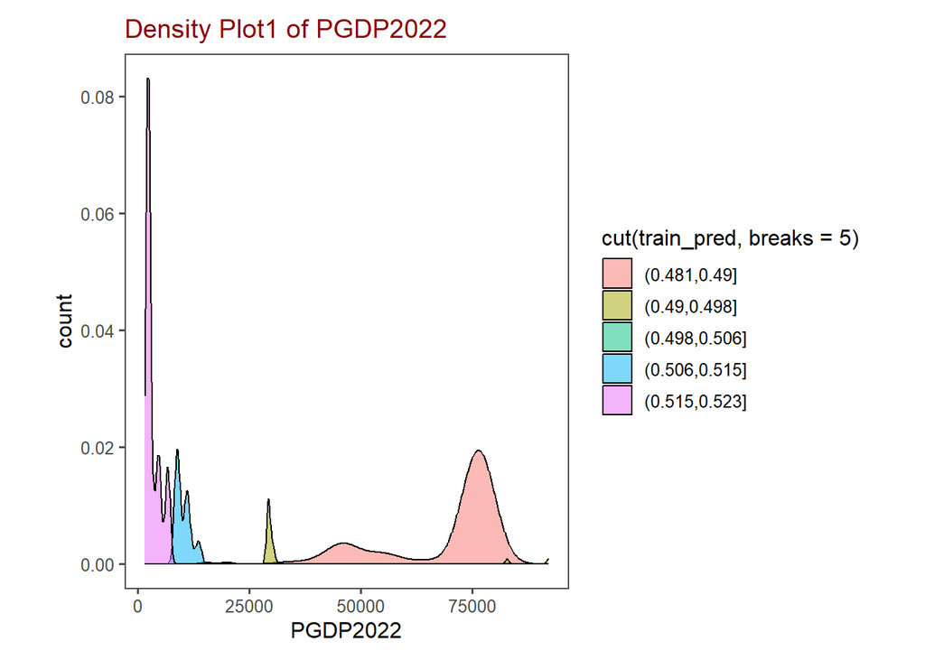

```r
library(ggplot2)

nb_plot1_data <- data.frame(
  PGDP2022 = train$X2022,
  nbpred1_train = train$nbpred
)

# Create a function to plot feature distributions as density plots(cite4: chatgpt 3.5)
nb_density_plot <- function(data, feature_name, train_pred) {
  ggplot(data, aes(x = data[[feature_name]], fill = cut(train_pred, breaks = 5))) +
    geom_density(aes(y = ..count..), alpha = 0.5) +
    labs(title = paste("Density Plot1 of", feature_name), x = feature_name)+project2_theme
}

# Create separate density plots for each feature
feature_names_nb1 <- c("PGDP2022")
for (feature in feature_names_nb1) {
  print(nb_density_plot(nb_plot1_data, feature, nb_plot1_data$nbpred1_train))
}
```

From this plot, we can find out that a country’s GDP per capita in 2022 doesn’t show a correlation with higher income of Youtube channels in this country.

Moreover, we want to research the correlation between total video views and the highest estimated yearly income.

```r
library('e1071')
outcome_nb <- "hyel_binary"
selVars_nb4 <- c("video.views")
pos <- 1
pPos <- sum(train[, outcome_nb] == pos) / length(train[, outcome_nb])

(f4 <- paste('as.factor(', outcome_nb, ' > 0) ~ ', paste(selVars_nb4, collapse=' + '), sep=''))
```

```
## [1] "as.factor(hyel_binary > 0) ~ video.views"
```

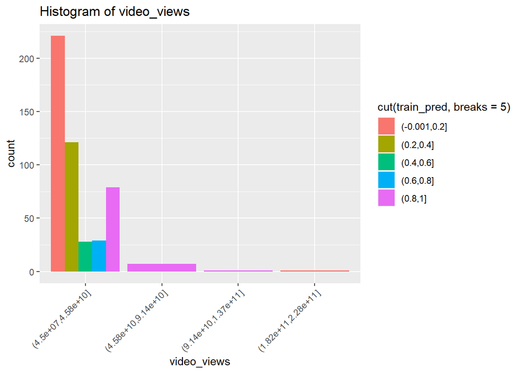

```r
nbmodel4 <- naiveBayes(as.formula(f4), data = train)
train$nbpred4 <- predict(nbmodel4, newdata=train,type='raw')[,"TRUE"]
test$nbpred4 <- predict(nbmodel4,newdata=test,type ='raw')[,'TRUE']

library(ggplot2)

nb_plot4_data <- data.frame(
  video_views = train$video.views,
  nbpred_videoviews = train$nbpred4
)

nb_histogram_plot <- function(data, feature_name, train_pred) {
  ggplot(data, aes(x = cut(data[[feature_name]], breaks = 5), fill = cut(train_pred, breaks = 5))) +
    geom_bar(position = "dodge") +
    labs(title = paste("Histogram of", feature_name), x = feature_name)+theme(axis.text.x = element_text(angle = 45, hjust = 1))
}

# Create separate density plots for each feature
feature_names_nb4 <- c("video_views")
for (feature in feature_names_nb4) {
  print(nb_histogram_plot(nb_plot4_data, feature, nb_plot4_data$nbpred_videoviews))
}
```

This histogram indicates that the Youtube channel who has more video views in this year, over 4.58e+10, are more likely to become a high income channel.

### Multivariate models

#### Decision Tree with feature selection1

In this section we will use the feature selection1 which was selected by Fisher’s score method as features, using Decision Tree model to predict.

```r
library(rpart)
formula_tree1 <- as.formula("hyel_binary ~ highest_monthly_earnings_fix1 + videoviews_monthlygrowthrate  +  Gross.tertiary.education.enrollment.... + Population") # feature selection 1

tree_model1 <- rpart(formula_tree1, data = train, method = "class",)

train$tree_pred1 <- predict(tree_model1, newdata=train,type="class")
test$tree_pred1 <- predict(tree_model1, newdata=test, type = "class")
```

Visualize decision tree model 1

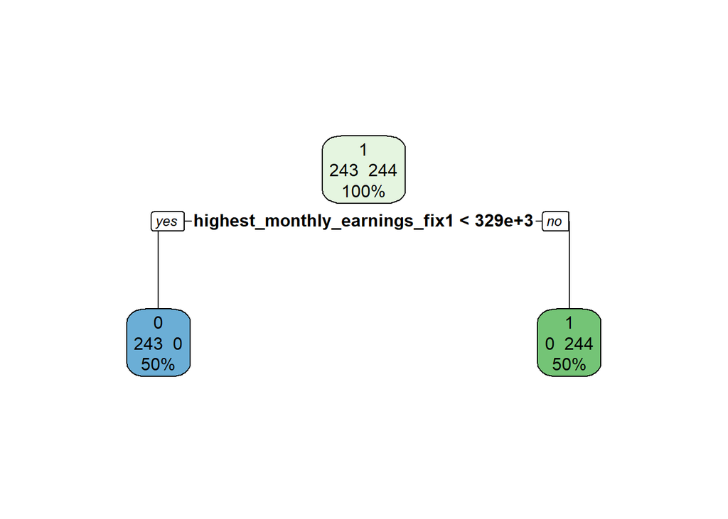

```r
library(rpart.plot)
rpart.plot(tree_model1, extra = 101, type = 2, fallen.leaves = TRUE)
```

#### Decision Tree with feature selection 2 In this section we will use the feature selection2 which was selected by Information gain method as features, using Decision Tree model to predict.

```r
library(rpart)
formula_tree2 <- as.formula("hyel_binary ~ highest_monthly_earnings_fix1 + videoviews_monthlygrowthrate  +  earnings_views + video.views + subscribers_for_last_30_days + subscribers") # feature selection 2

tree_model2 <- rpart(formula_tree2, data = train, method = "class",)

train$tree_pred2 <- predict(tree_model2, newdata=train,type="class")
test$tree_pred2 <- predict(tree_model2, newdata=test, type = "class")
```

Visualize decision tree model 2

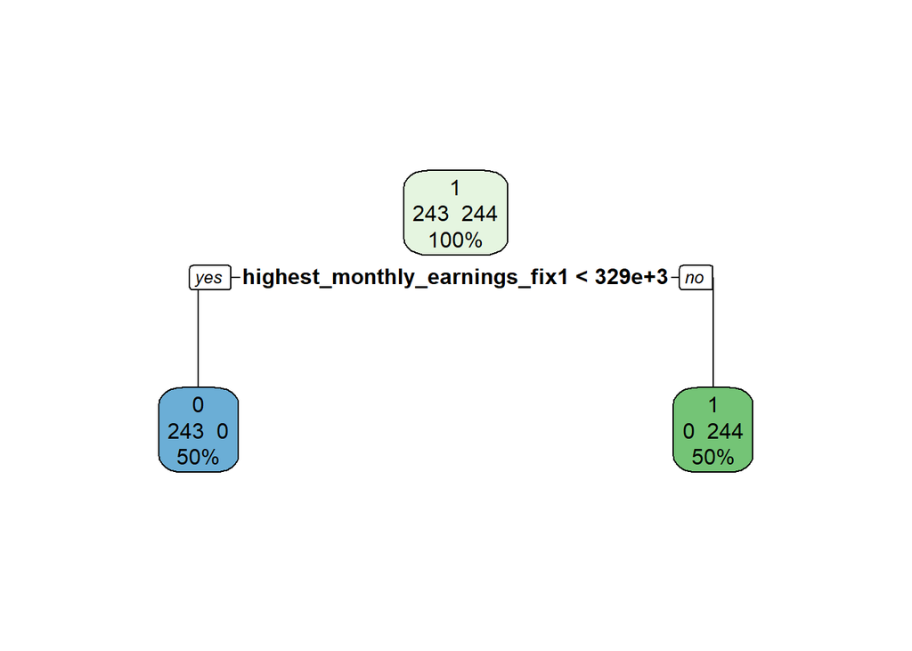

```r
library(rpart.plot)
rpart.plot(tree_model2, extra = 101, type = 2, fallen.leaves = TRUE)
```

This plot indicates that 50% of Youtube channles’ highest estimated monthly income is lower than 329000, and if a Youtube channel’s highest estimated monthly income is higher than 329000, then its highest estimated yearly income has a 100% probability of being higher than the median and vice versa.

We can see that in both decision tree model, the highest estimated monthly income is the most significant feature which only shown on the decision tree. Let’s try to make a decision tree model which excludes this feature and include all other features in selection 1 and selection 2.

#### Decision Tree with all the selected features excluding “highest_monthly_earnings_fix1”

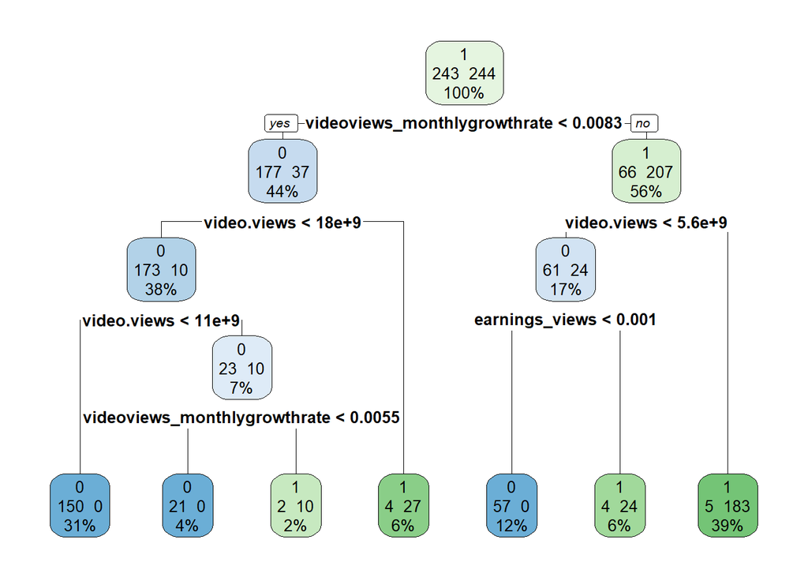

```r
library(rpart)
formula_tree3 <- as.formula("hyel_binary ~ videoviews_monthlygrowthrate  +  earnings_views + video.views + subscribers_for_last_30_days + subscribers + Gross.tertiary.education.enrollment.... + Population ") # all the selected features excluding "highest_monthly_earnings_fix1"

tree_model3 <- rpart(formula_tree3, data = train, method = "class",)

train$tree_pred3 <- predict(tree_model3, newdata=train,type="class")
test$tree_pred3 <- predict(tree_model3, newdata=test, type = "class")

library(rpart.plot)
rpart.plot(tree_model3, extra = 101, type = 2, fallen.leaves = TRUE)
```

As we defined before, class 0 means ‘low income’ which means this Youtube channel’s highest estimated yearly income is lower than the median, class 1 means ‘high income’. This decision tree model indicates that the 85% of high income Youtube channels have video views growth rate more than 0.83%, and 75% of them have more than 5.6e+9 video views in the last year, which means the Youtube channel who has higher video views growth rate(higher than 0.83%) and higher video views in the last year (higher than 5.6e+9) are more likely to become a high income Youtube channel.

#### Naïve Bayes model with feature selection 1

In this section we will use the feature selection1 which was selected by Fisher’s score method as features, using Naïve Bayes model to predict.

```r
library('e1071')
outcome_nb <- "hyel_binary"
selVars_nb2 <- c("highest_monthly_earnings_fix1","videoviews_monthlygrowthrate","Gross.tertiary.education.enrollment....","Population")
pos <- 1
pPos <- sum(train[, outcome_nb] == pos) / length(train[, outcome_nb])

(f2 <- paste('as.factor(', outcome_nb, ' > 0) ~ ', paste(selVars_nb2, collapse=' + '), sep=''))
```

```
## [1] "as.factor(hyel_binary > 0) ~ highest_monthly_earnings_fix1 + videoviews_monthlygrowthrate + Gross.tertiary.education.enrollment.... + Population"
```

```r
nbmodel2 <- naiveBayes(as.formula(f2), data = train)

train$nbpred2 <- predict(nbmodel2, newdata=train,type='raw')[,"TRUE"]
test$nbpred2 <- predict(nbmodel2,newdata=test,type ='raw')[,'TRUE']

output_train_nb2 <- data.frame(
  highest_monthly_earnings = train$highest_monthly_earnings_fix1,
  video_views_monthly_growth_rate = train$videoviews_monthlygrowthrate,
  Gross.tertiary.education.enrollment = train$Gross.tertiary.education.enrollment....,
  Population = train$Population,
  nbpred2_train = train$nbpred2
)

output_test_nb2 <- data.frame(
  highest_monthly_earnings = test$highest_monthly_earnings_fix1,
  video_views_monthly_growth_rate = test$videoviews_monthlygrowthrate,
  Gross.tertiary.education.enrollment = test$Gross.tertiary.education.enrollment....,
  Population = test$Population,
  nbpred2_test = test$nbpred2
)


cat("First few rows of train prediction nbmodel 2:\n")
```

```
## First few rows of train prediction nbmodel 2:
```

```r
print(head(output_train_nb2))
```

```
##   highest_monthly_earnings video_views_monthly_growth_rate
## 1                  9000000                     0.010002569
## 2                  2900000                     0.007908675
## 3                   156700                     0.001350294
## 4                  2300000                     0.007579335
## 5                  3200000                     0.014085457
## 6                  2900000                     0.009315318
##   Gross.tertiary.education.enrollment Population nbpred2_train
## 1                                28.1 1366417754  5.733064e-12
## 2                                88.2  328239523  1.000000e+00
## 3                                63.2  126226568  6.865812e-03
## 4                                88.2  328239523  1.000000e+00
## 5                                28.1 1366417754  1.000000e+00
## 6                                88.2  328239523  1.000000e+00
```

```r
cat("\nFirst few rows of test prediction nb model 2:\n")
```

```
##
## First few rows of test prediction nb model 2:
```

```r
print(head(output_test_nb2))
```

```
##   highest_monthly_earnings video_views_monthly_growth_rate
## 1                  5400000                     0.049887417
## 2                  7900000                     0.012189477
## 3                  7300000                     0.012478109
## 4                  6600000                     0.016679585
## 5                  2400000                     0.010798273
## 6                  1000000                     0.009073816
##   Gross.tertiary.education.enrollment Population nbpred2_test
## 1                                88.2  328239523 9.999662e-01
## 2                                88.2  328239523 1.195898e-10
## 3                                28.1 1366417754 6.881581e-09
## 4                                28.1 1366417754 1.760710e-07
## 5                                90.0   44938712 1.000000e+00
## 6                                28.1 1366417754 1.000000e+00
```

We can visualize this result.

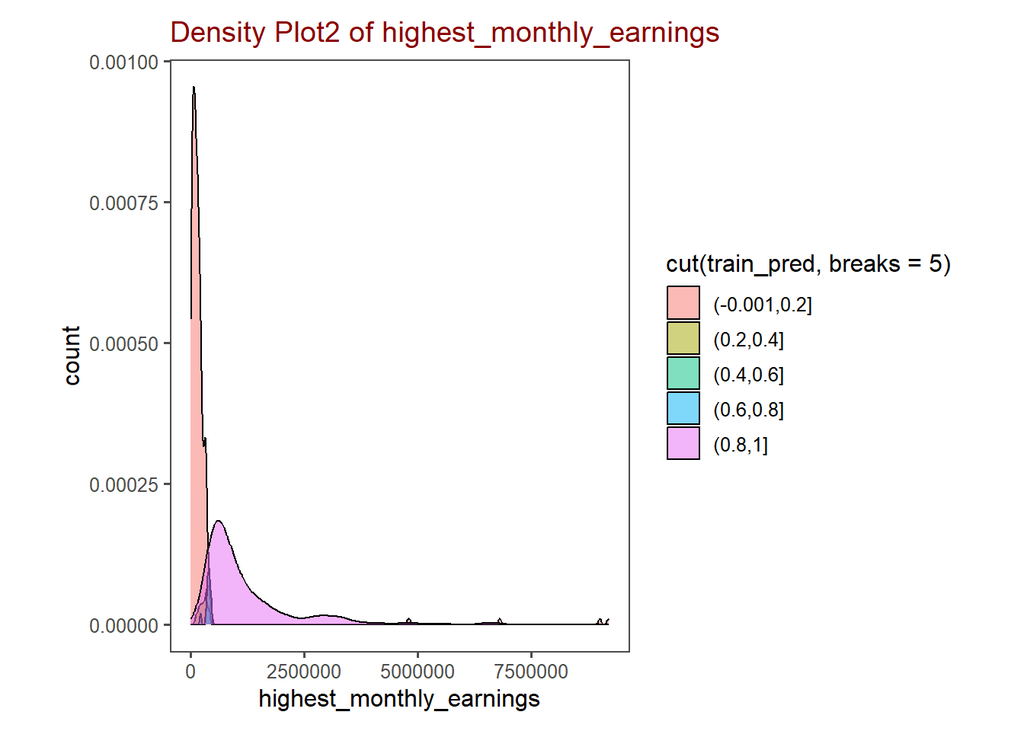

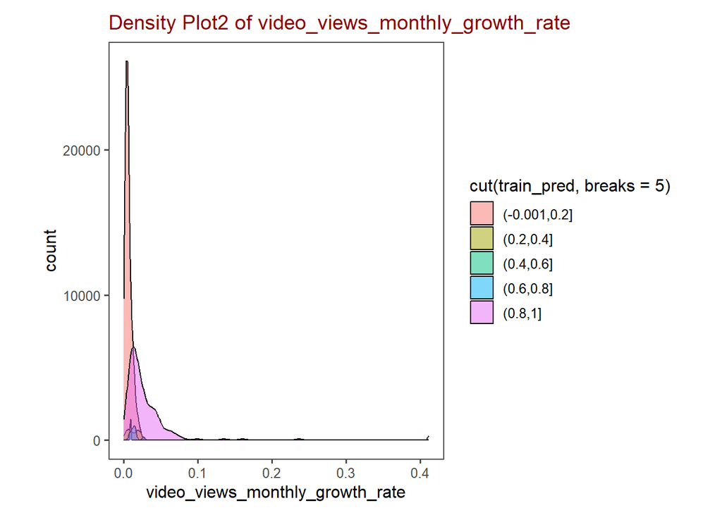

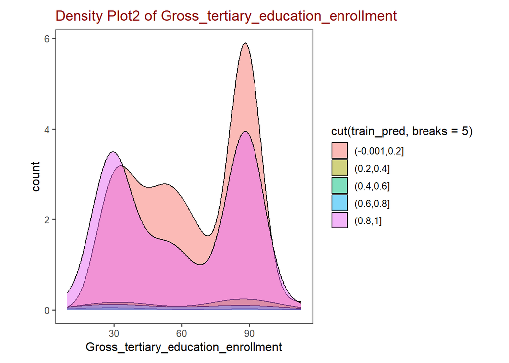

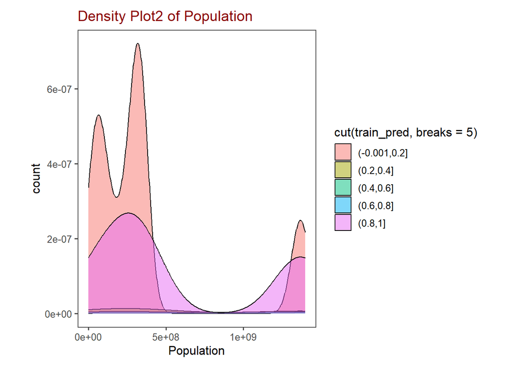

```r
library(ggplot2)

nb_plot2_data <- data.frame(
  highest_monthly_earnings = train$highest_monthly_earnings_fix1,
  video_views_monthly_growth_rate = train$videoviews_monthlygrowthrate,
  Gross_tertiary_education_enrollment = train$Gross.tertiary.education.enrollment....,
  Population = train$Population,
  nbpred2_train = train$nbpred2
)

nb_density_plot2 <- function(data, feature_name, train_pred) {
  ggplot(data, aes(x = data[[feature_name]], fill = cut(train_pred, breaks = 5))) +
    geom_density(aes(y = ..count..), alpha = 0.5) +
    labs(title = paste("Density Plot2 of", feature_name), x = feature_name)+project2_theme
}
# Create separate density plots for each feature
feature_names_nb2 <- c("highest_monthly_earnings", "video_views_monthly_growth_rate",
                   "Gross_tertiary_education_enrollment", "Population")
for (feature in feature_names_nb2) {
  print(nb_density_plot2(nb_plot2_data, feature, nb_plot2_data$nbpred2_train))
}
```

From this plots, we can see that higher highest estimated monthly earnings and video views monthly growth rate show a relative positive correlation with higher yearly income, while the gross tertiary education enrollment and population show positive correlation in both left and right tails.

#### Naïve Bayes model with feature selection 2

In this section we will use the feature selection2 which was selected by Information gain method as features, using Naïve Bayes model to predict.

```r
library('e1071')
outcome_nb <- "hyel_binary"
selVars_nb3 <- c("highest_monthly_earnings_fix1","videoviews_monthlygrowthrate","video.views","earnings_views","subscribers_for_last_30_days","subscribers")
pos <- 1
pPos <- sum(train[, outcome_nb] == pos) / length(train[, outcome_nb])

(f3 <- paste('as.factor(', outcome_nb, ' > 0) ~ ', paste(selVars_nb3, collapse=' + '), sep=''))
```

```
## [1] "as.factor(hyel_binary > 0) ~ highest_monthly_earnings_fix1 + videoviews_monthlygrowthrate + video.views + earnings_views + subscribers_for_last_30_days + subscribers"
```

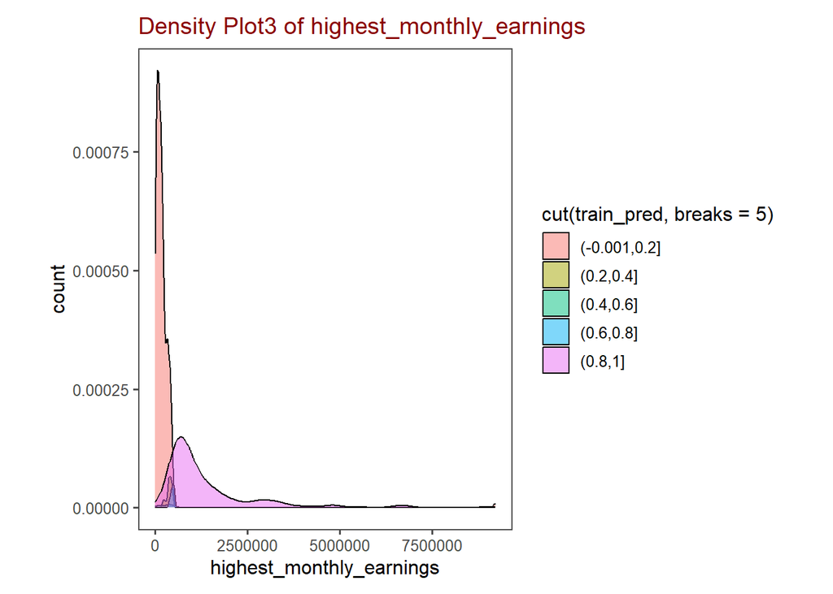

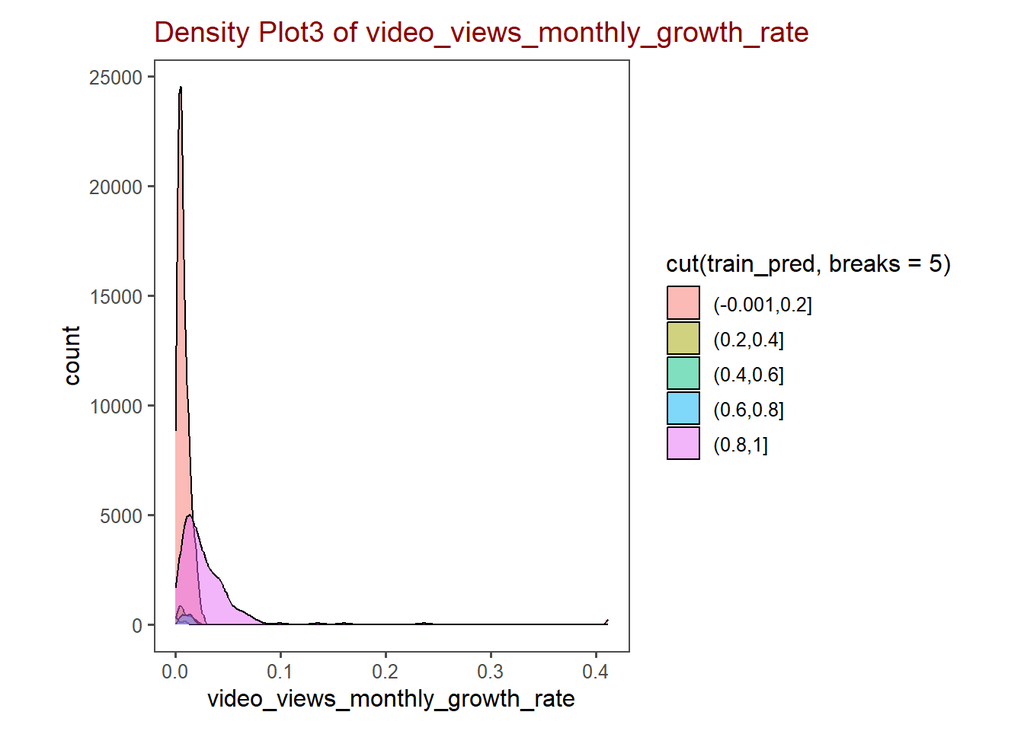

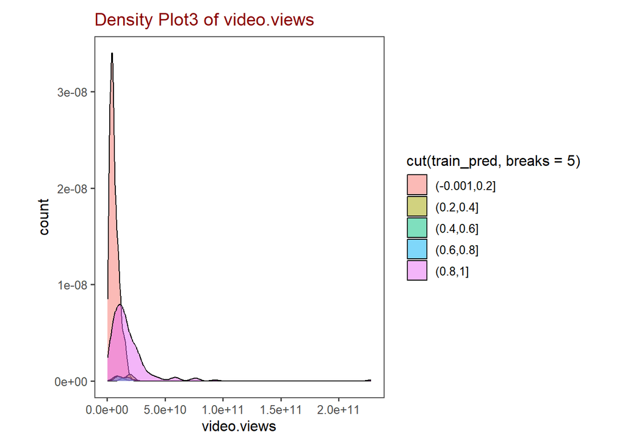

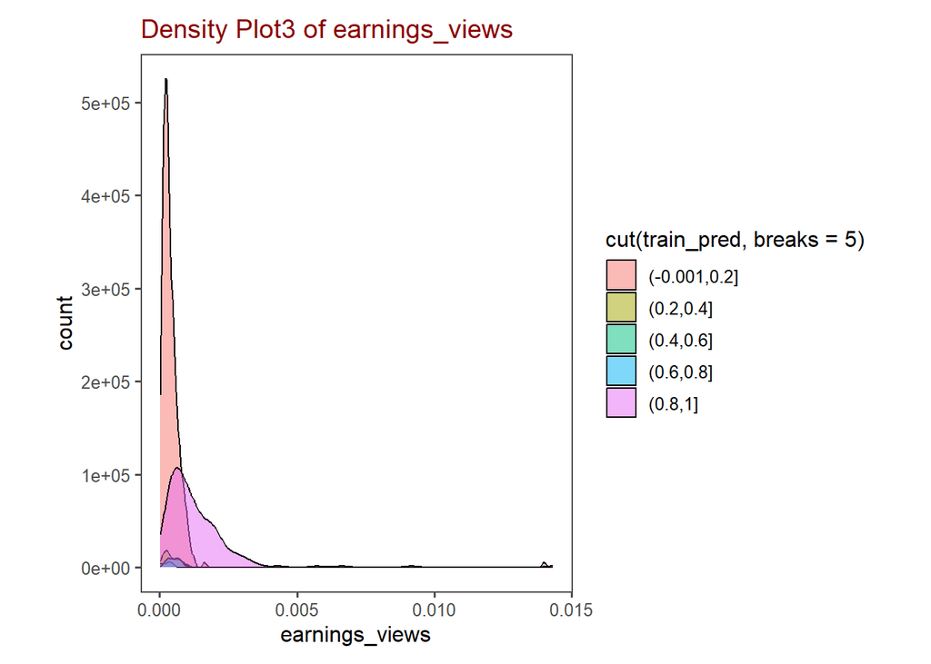

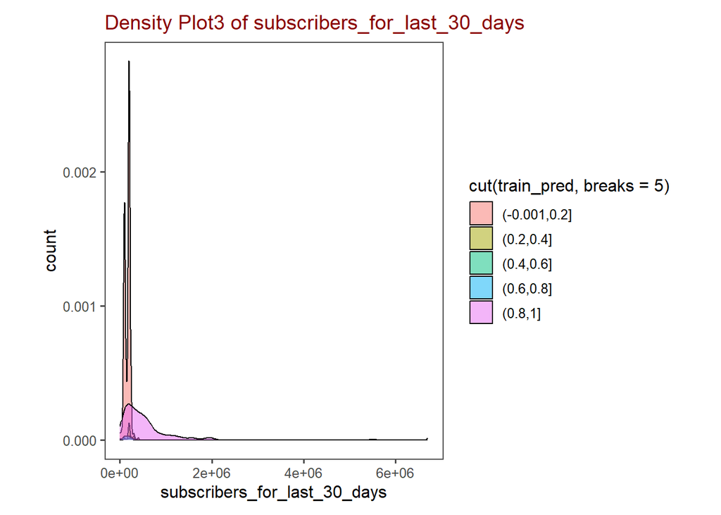

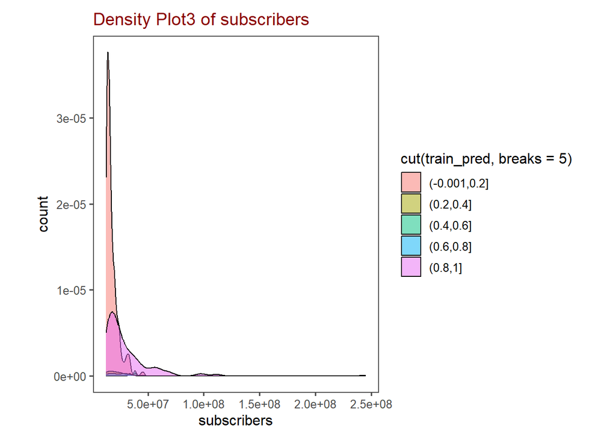

```r
nbmodel3 <- naiveBayes(as.formula(f3), data = train)

train$nbpred3 <- predict(nbmodel3, newdata=train,type='raw')[,"TRUE"]
test$nbpred3 <- predict(nbmodel3,newdata=test,type ='raw')[,'TRUE']

#Visualize the result
library(ggplot2)

# Assuming 'nbpred2_train' is a column in your 'train' dataset
# Create a new data frame with features and 'nbpred2_train'
nb_plot3_data <- data.frame(
  highest_monthly_earnings = train$highest_monthly_earnings_fix1,
  video_views_monthly_growth_rate = train$videoviews_monthlygrowthrate,
  video.views = train$video.views,
  earnings_views = train$earnings_views,
  subscribers_for_last_30_days = train$subscribers_for_last_30_days,
  subscribers = train$subscribers,
  nbpred3_train = train$nbpred3
)

nb_density_plot3 <- function(data, feature_name, train_pred) {
  ggplot(data, aes(x = data[[feature_name]], fill = cut(train_pred, breaks = 5))) +
    geom_density(aes(y = ..count..), alpha = 0.5) +
    labs(title = paste("Density Plot3 of", feature_name), x = feature_name)+project2_theme
}

# Create separate density plots for each feature
feature_names_nb3 <- c("highest_monthly_earnings", "video_views_monthly_growth_rate",
                   "video.views", "earnings_views","subscribers_for_last_30_days","subscribers")
for (feature in feature_names_nb3) {
  print(nb_density_plot3(nb_plot3_data, feature, nb_plot3_data$nbpred3_train))
}
```

From these plots, we can see that higher highest estimated monthly earnings, video views monthly growth rate, total video views, earning rate(earning/views, which indicates a earning rate), subscribers in last 30 days and all the subscribers all show a relative positive correlation with higher yearly income.

### Comparison of the combinations of feature selection techniques and classifiers

Firstly, the feature selection techniques. From the Naive Bayes model’s results, all the features selected by Information gain show a positive correlation with the response variable, while there are two variables(gross tertiary education enrollment and population) which are selected by Fisher score don’t show a positive correlation with the response variable. So we can draw a conclusion that based on this project, Information gain might be more accurate.

Secondly, the classifiers. Both Naive Bayes model and decision tree are easy to use.

They are both used primarily for classification tasks, predicting the class or category to which a data point belongs.

Naive Bayes models calculate the probability to each class while decision tree shows a tree structure with conditions and leaf nodes.

They both show that a Youtube channel’s highest estimated monthly earning, video views monthly growth rate, earning rate and video views in total show a positive correlation with the yearly income, while decision tree clearly shows the conditions of nodes, so we can tell the decision path easily, but Naive Bayes models don’t show decision path. However, because of decision tree’s algorithm, it only shows the result of most significant features, so some other less significant features’ results may not be shown.

### Evaluation

In this section, we are going to evaluate each model based on their precision, recall, F1 score and accuracy.

```r
# Define a function to evaluate models
performanceMeasures <- function(model_name, pred, truth) {
  ctable <- table(truth = truth, pred = pred)
  accuracy <- sum(diag(ctable)) / sum(ctable)
  precision <- ifelse(sum(ctable[, 2]) == 0, 0, ctable[2, 2] / sum(ctable[, 2]))
  recall <- ifelse(sum(ctable[2, ]) == 0, 0, ctable[2, 2] / sum(ctable[2, ]))
  f1 <- ifelse((precision + recall) == 0, 0, 2 * (precision * recall) / (precision + recall))

  return(data.frame(Model = model_name, Precision = precision, Recall = recall, F1 = f1, Accuracy = accuracy))
}

# Output the results(cite5:chatgpt3.5)
results_df <- data.frame(Model = character(0), Precision = numeric(0), Recall = numeric(0), F1 = numeric(0), Accuracy = numeric(0))

results_df <- rbind(results_df, performanceMeasures("nb_single1, training", train$nbpred, train$hyel_binary))
results_df <- rbind(results_df, performanceMeasures("nb_single1, testing", test$nbpred, test$hyel_binary))
results_df <- rbind(results_df, performanceMeasures("nb_single2, training", train$nbpred4, train$hyel_binary))
results_df <- rbind(results_df, performanceMeasures("nb_single2, test", test$nbpred4, test$hyel_binary))
results_df <- rbind(results_df, performanceMeasures("decision_tree1, training", train$tree_pred1, train$hyel_binary))
results_df <- rbind(results_df, performanceMeasures("decision_tree1, test", test$tree_pred1, test$hyel_binary))
results_df <- rbind(results_df, performanceMeasures("decision_tree2, training", train$tree_pred2, train$hyel_binary))
results_df <- rbind(results_df, performanceMeasures("decision_tree2, test", test$tree_pred2, test$hyel_binary))
results_df <- rbind(results_df, performanceMeasures("decision_tree3, training", train$tree_pred3, train$hyel_binary))
results_df <- rbind(results_df, performanceMeasures("decision_tree3, test", test$tree_pred3, test$hyel_binary))
results_df <- rbind(results_df, performanceMeasures("nb_multi1, training", train$nbpred2, train$hyel_binary))
results_df <- rbind(results_df, performanceMeasures("nb_multi1, test", test$nbpred2, test$hyel_binary))
results_df <- rbind(results_df, performanceMeasures("nb_multi2, training", train$nbpred3, train$hyel_binary))
results_df <- rbind(results_df, performanceMeasures("nb_multi2, test", test$nbpred3, test$hyel_binary))

print(results_df)
```

```
##                       Model Precision      Recall          F1    Accuracy
## 1      nb_single1, training 0.0000000 0.000000000 0.000000000 0.004106776
## 2       nb_single1, testing 0.7500000 0.034090909 0.065217391 0.021621622
## 3      nb_single2, training 0.0000000 0.000000000 0.000000000 0.000000000
## 4          nb_single2, test 0.0000000 0.000000000 0.000000000 0.005405405
## 5  decision_tree1, training 1.0000000 1.000000000 1.000000000 1.000000000
## 6      decision_tree1, test 1.0000000 1.000000000 1.000000000 1.000000000
## 7  decision_tree2, training 1.0000000 1.000000000 1.000000000 1.000000000
## 8      decision_tree2, test 1.0000000 1.000000000 1.000000000 1.000000000
## 9  decision_tree3, training 0.9420849 1.000000000 0.970178926 0.969199179
## 10     decision_tree3, test 0.8800000 1.000000000 0.936170213 0.935135135
## 11      nb_multi1, training 1.0000000 0.004098361 0.008163265 0.002053388
## 12          nb_multi1, test 1.0000000 0.011363636 0.022471910 0.005405405
## 13      nb_multi2, training 0.0000000 0.000000000 0.000000000 0.000000000
## 14          nb_multi2, test 0.0000000 0.000000000 0.000000000 0.005405405
```

## Part 2 - Clustering

Select the variables ‘subscribers’, ‘video.views’, “earnings_views”, “videoviews_monthlygrowthrate”, “subscribers_for_last_30_days”, ‘highest_monthly_earnings_fix1’, “Gross.tertiary.education.enrollment….”, “Population” for cluster analysis .

This part uses k-means clustering and hierarchical clustering methods respectively. The NbClust package provides numerous indices to determine the optimal number of classes in a cluster analysis. The data of the best class for k-means clustering is 2.The data of the best class for hierarchical clustering is 2.

### k-means

videoviews_monthlygrowthrate + earnings_views + video.views + subscribers_for_last_30_days + subscribers + Gross.tertiary.education.enrollment…. + Population

```r
# Ensure there are no missing values in the data, and extract the required columns
data <- Youtubesta5[, c('subscribers', 'video.views',"earnings_views","videoviews_monthlygrowthrate", "subscribers_for_last_30_days",'highest_monthly_earnings_fix1',"Gross.tertiary.education.enrollment....","Population")]
```

According to the majority rule, the best number of clusters is 2

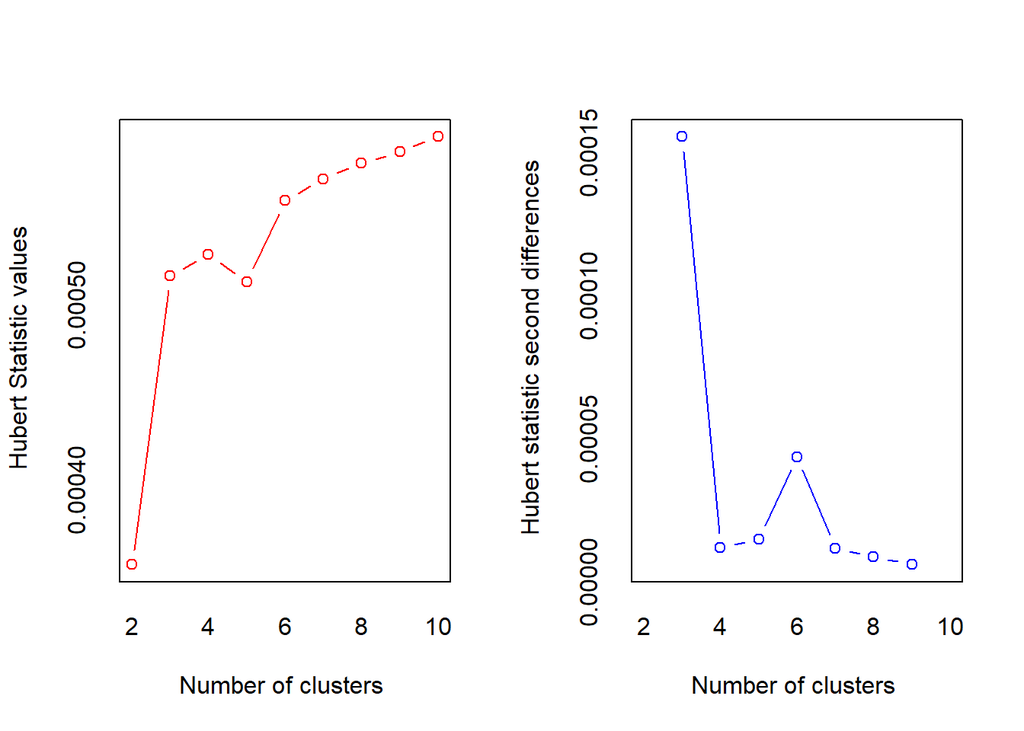

```
## *** : The Hubert index is a graphical method of determining the number of clusters.
##                 In the plot of Hubert index, we seek a significant knee that corresponds to a
##                 significant increase of the value of the measure i.e the significant peak in Hubert
##                 index second differences plot.
##
```

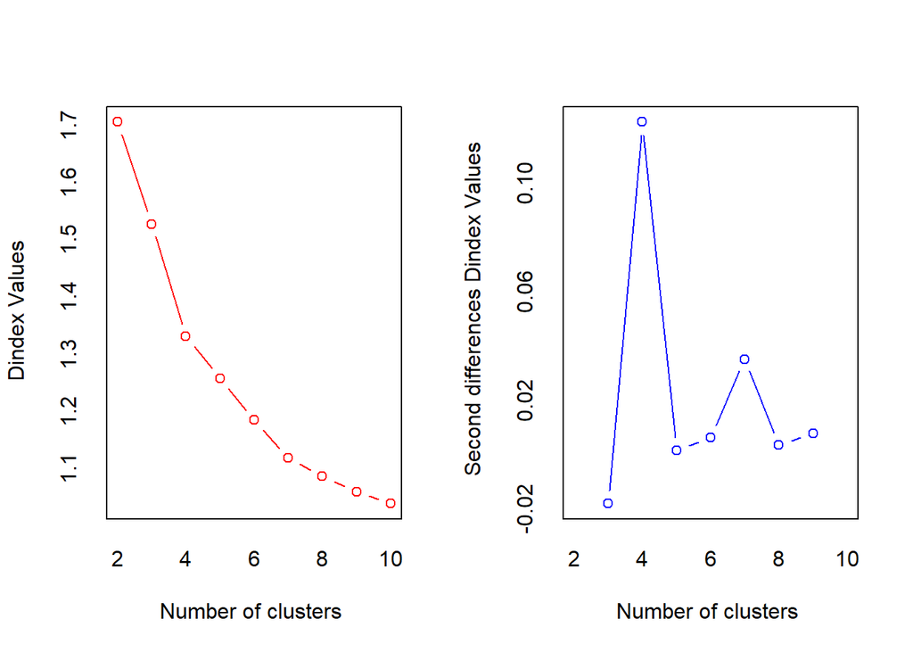

```
## *** : The D index is a graphical method of determining the number of clusters.
##                 In the plot of D index, we seek a significant knee (the significant peak in Dindex
##                 second differences plot) that corresponds to a significant increase of the value of
##                 the measure.
##
## * Among all indices:
## * 7 proposed 2 as the best number of clusters
## * 6 proposed 3 as the best number of clusters
## * 4 proposed 4 as the best number of clusters
## * 1 proposed 5 as the best number of clusters
## * 2 proposed 6 as the best number of clusters
## * 1 proposed 7 as the best number of clusters
## * 1 proposed 8 as the best number of clusters
## * 1 proposed 10 as the best number of clusters
##
##                    ***** Conclusion *****
##
## * According to the majority rule, the best number of clusters is  2
##
##
```

```r
# standardize the data
data_scaled <- scale(data)
library(NbClust)
#
num_1 <- NbClust(data_scaled, min.nc=2, max.nc=10, method="kmeans")
```

```r
# 7 evaluation criteria recommend 2 as the optimal number of clusters

table(num_1$Best.n[1,])
```

```
##
##  0  1  2  3  4  5  6  7  8 10
##  2  1  7  6  4  1  2  1  1  1
```

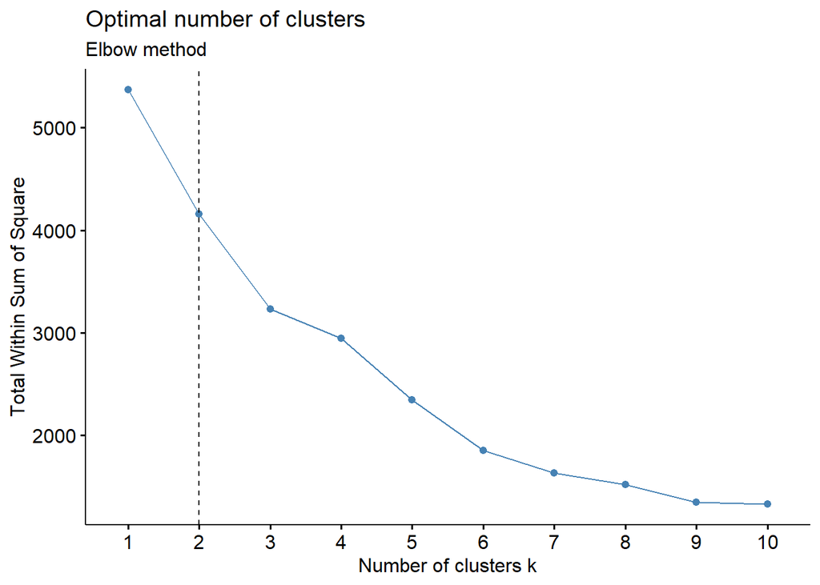

```r
library(cluster)    # clustering algorithms
library(factoextra) # clustering algorithms & visualization

# Elbow method (cite6:Chatgpt 3.5)
fviz_nbclust(data_scaled, kmeans, method = "wss") +
    geom_vline(xintercept = 2, linetype = 2)+
  labs(subtitle = "Elbow method")
```

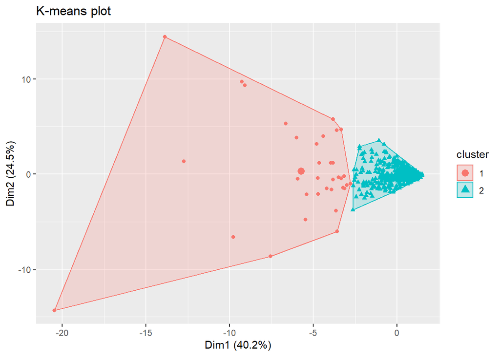

```r
# K-means clustering with 2 clusters
k5 <- kmeans(data_scaled, centers = 2, nstart = 25)

# Visualize clusters
p5<-fviz_cluster(k5, data = data_scaled, geom="point",main = "K-means plot")

p5
```

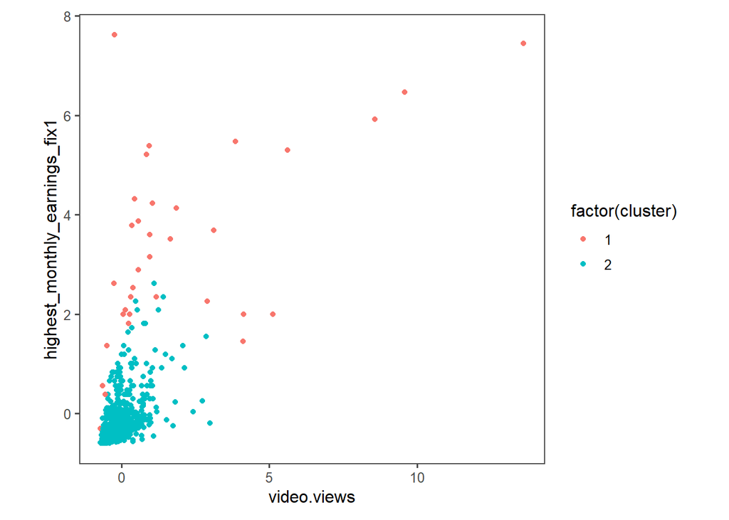

```r
library(tidyverse)
library(ggplot2)

# Visualize clusters with video.views on x-axis and highest_monthly_earnings_fix1 on y-axis


##cluster 1 mainly displays the group with the highest_monthly_earnings_fix1 under the same video.views situation.
##cluster 2 mainly shows the group with the lowest highest_monthly_earnings_fix1 under the same video.views situation.


Pk5<- data_scaled %>%
  as_tibble() %>%
  mutate(cluster = k5$cluster
         ) %>%
  ggplot(aes(video.views,highest_monthly_earnings_fix1, color = factor(cluster)))+
  geom_point()+project2_theme


Pk5
```

In the scatter plot of highest estimated monthly earning and video views, we can find out that video views shows a positive correlation with monthly income.

### hierarchical clustering

```
## [1] "Frey index : No clustering structure in this data set"
```

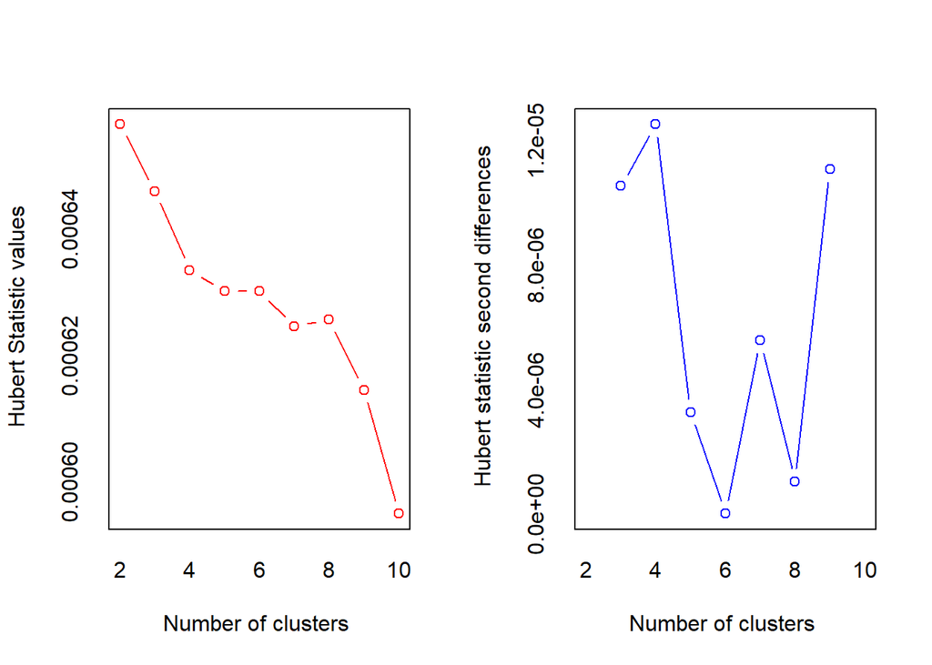

```
## *** : The Hubert index is a graphical method of determining the number of clusters.
##                 In the plot of Hubert index, we seek a significant knee that corresponds to a
##                 significant increase of the value of the measure i.e the significant peak in Hubert
##                 index second differences plot.
##
```

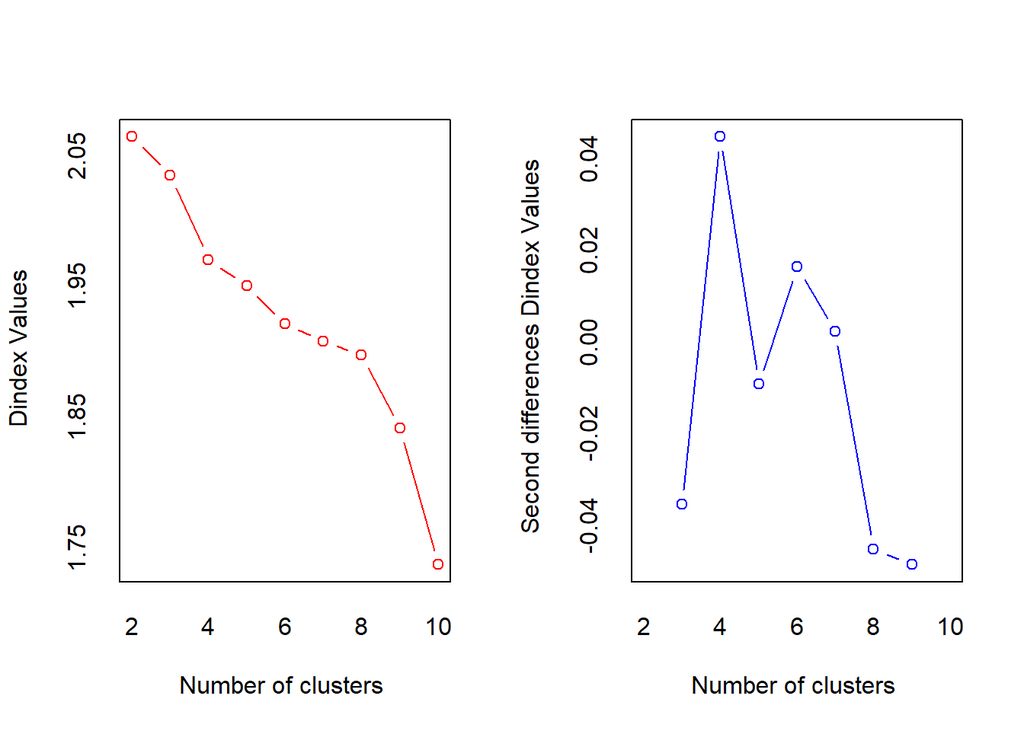

```
## *** : The D index is a graphical method of determining the number of clusters.
##                 In the plot of D index, we seek a significant knee (the significant peak in Dindex
##                 second differences plot) that corresponds to a significant increase of the value of
##                 the measure.
##
## * Among all indices:
## * 8 proposed 2 as the best number of clusters
## * 3 proposed 3 as the best number of clusters
## * 5 proposed 4 as the best number of clusters
## * 3 proposed 5 as the best number of clusters
## * 1 proposed 6 as the best number of clusters
## * 1 proposed 8 as the best number of clusters
## * 2 proposed 10 as the best number of clusters
##
##                    ***** Conclusion *****
##
## * According to the majority rule, the best number of clusters is  2
##
##
```

```r
# Determine optimal number of clusters (cite7:Chatgpt 3.5)
number2 <- NbClust(data_scaled, distance="euclidean",
                  min.nc=2, max.nc=10, method="average")
```

```r
table(number2$Best.n[1,])
```

```
##
##  0  2  3  4  5  6  8 10
##  2  8  3  5  3  1  1  2
```

```r
# Calculate distance matrix
d <- dist(data_scaled)
# Hierarchical clustering
fit.average <- hclust(d, method="average")
# Get final clustering scheme with 2 clusters
clusters <- cutree(fit.average, k=2)
table(clusters)
```

```
## clusters
##   1   2
## 671   1
```

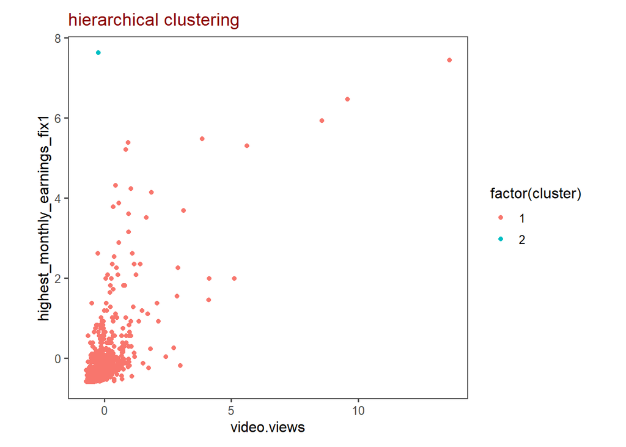

```r
# Visualize clusters
p_hclust<-fviz_cluster(list(data = data_scaled, cluster = clusters),main = "hierarchical  clustering plot")  ## from ‘factoextra’ package


# Visualize clusters with video.views on x-axis and highest_monthly_earnings_fix1 on y-axis

##cluster 1 mainly shows the highest_monthly_earnings_fix1 normal group under the same video.views situation.
##cluster 2 mainly shows the group with extremely high highest_monthly_earnings_fix1 under the same video.views situation.


p_hclust_5<- data_scaled %>%
  as_tibble() %>%
  mutate(cluster = clusters
         ) %>%
  ggplot(aes(video.views,highest_monthly_earnings_fix1, color = factor(cluster)))+
  geom_point()+
  labs(title = "hierarchical clustering ")+project2_theme



p_hclust_5
```

## Conclusion

In conclusion, we used Fisher’s score and information gain as feature selection techniques, and used Decision tree and Naive Bayes model to predict. We find out that both models show this result: a Youtube channel’s video views in the last year, video views monthly growth rate, highest estimated monthly earnings, subscribers, earning rate and the number of subscribers increase in the last 30 days show a positive correlation with highest estimated yearly earning, while Population, GDP per capita and gross tertiary education enrollment don’t show a significant correlation with the highest estimated yearly income.

## Citation of AI tool

In this project, we used AI as a tool to help us study. The following are the citations, and the citations are clearly shown in the code.

Cite1: source: OpenAi, model: GPT3.5. I asked chatgpt to help me generate a code to discard some outliers based on the z-score. Here, I create a new data ‘Youtubesta5’ to store the filtered data, and make sure the outcome is reproducible. As the range of income of different Youtube channels may be very wide, I choose 3 as the z threshold.

Cite2: source: OpenAi, model: GPT3.5. I asked chatgpt to help me generate a code to calculate features’ fisher score. Here, I need to convert some character variables to numeric variables because we can’t calculate character variables’ fisher score. I also omit some NA values to make the arguments in same length. Finally, I created a list called ‘ranked_feature1’ to select the top features in fisher score.

Cite6:source: OpenAi, model: GPT3.5.Consulted chatgpt about the way the number of clusters is determined and fix the code about Get final clustering scheme with 2 clusters